# Signlaomes

Taiyun Kim, Hani Jieun Kim, and Di Xiao

1 June 2020

#### Package

BiocStyle 2.14.4

## 0.1 Introduction

A key component of the `PhosR` package is to construct signalomes. The signalome construction is composed of two main steps: 1) kinase-substrate relationsip scoring and 2) signalome construction. This involves a sequential workflow where the outputs of the first step are used as inputs of the latter step.

In brief, our kinase-substrate relationship scoring method (`kinaseSubstrateScore` and `kinaseSubstratePred`) prioritises potential kinases that could be responsible for the phosphorylation change of phosphosite on the basis of kinase recognition motif and phosphoproteomic dynamics. Using the kinase-substrate relationships derived from the scoring methods, we reconstruct signalome networks present in the data (`Signalomes`) wherin we highlight kinase regulation of discrete modules.

## 0.2 Loading packages and data

First, we will load the `PhosR` package along with few other packages that we will be using in this section of the vignette.

```r
suppressPackageStartupMessages({
  library(PhosR)
  library(dplyr)
  library(ggplot2)
  library(GGally)
  library(ggpubr)
  library(calibrate)
})
```

We will also be needing data containing kinase-substrate annotations from `PhosphoSitePlus`, kinase recognition motifs from `kinase motifs`, and annotations of kinase families from `kinase family`.

```r
data("PhosphoSitePlus")
data("KinaseMotifs")
data("KinaseFamily")
data("SPSs")
```

## 0.3 Setting up the data

As before, we will set up the data by cleaning up the phoshophosite labels and performing RUV normalisation.

```r
data("phospho_L6_ratio")
data("SPSs")

grps = gsub("_.+", "", colnames(phospho.L6.ratio))

# Cleaning phosphosite label
phospho.site.names = rownames(phospho.L6.ratio)
L6.sites = gsub(" ", "", sapply(strsplit(rownames(phospho.L6.ratio), "~"),
                                 function(x){paste(toupper(x[2]), x[3], "", sep=";")}))
phospho.L6.ratio = t(sapply(split(data.frame(phospho.L6.ratio), L6.sites), colMeans))
phospho.site.names = split(phospho.site.names, L6.sites)

# Construct a design matrix by condition
design = model.matrix(~ grps - 1)

# phosphoproteomics data normalisation using RUV
ctl = which(rownames(phospho.L6.ratio) %in% SPSs)
phospho.L6.ratio.RUV = RUVphospho(phospho.L6.ratio, M = design, k = 3, ctl = ctl)
```

## 0.4 Generation of kinase-substrate relationship scores

Next, we will filtered for dynamically regulated phosphosites and then standardise the filtered matrix.

```r
phosphoL6 = phospho.L6.ratio.RUV
rownames(phosphoL6) = phospho.site.names

# filter for up-regulated phosphosites
phosphoL6.mean <- meanAbundance(phosphoL6, grps = gsub("_.+", "", colnames(phosphoL6)))
aov <- matANOVA(mat=phosphoL6, grps=gsub("_.+", "", colnames(phosphoL6)))
phosphoL6.reg <- phosphoL6[(aov < 0.05) & (rowSums(phosphoL6.mean > 0.5) > 0), ,drop = FALSE]
L6.phos.std <- standardise(phosphoL6.reg)
rownames(L6.phos.std) <- sapply(strsplit(rownames(L6.phos.std), "~"), function(x){gsub(" ", "", paste(toupper(x[2]), x[3], "", sep=";"))})
```

We next extract the kinase recognition motifs from each of the phosphosites.

```r
L6.phos.seq <- sapply(strsplit(rownames(phosphoL6.reg), "~"), function(x)x[4])
```

Now that we have all the inputs for `kinaseSubstrateScore` and `kinaseSubstratePred` ready, we can proceed to the generation of kinase-substrate relationship scores.

```r
L6.matrices <- kinaseSubstrateScore(PhosphoSite.mouse, L6.phos.std, L6.phos.seq, numMotif = 5, numSub = 1)
```

```
## [1] "Number of kinases passed motif size filtering: 114"
## [1] "Number of kinases passed profile size filtering: 44"
## [1] "Scoring phosphosites against kinase motifs:"
## 1.2.3.4.5.6.7.8.9.10.11.12.13.14.15.16.17.18.19.20.21.22.23.24.25.26.27.28.29.30.31.32.33.34.35.36.37.38.39.40.41.42.43.44.45.46.47.48.49.50.51.52.53.54.55.56.57.58.59.60.61.62.63.64.65.66.67.68.69.70.71.72.73.74.75.76.77.78.79.80.81.82.83.84.85.86.87.88.89.90.91.92.93.94.95.96.97.98.99.100.101.1…
## Scoring phosphosites against kinase-substrate profiles:[1] "done."
## Generating combined scores for phosphosites by motifs and phospho profiles:[1] "done."
```

[figure not shown]

```r
set.seed(1)
L6.predMat <- kinaseSubstratePred(L6.matrices, top=30)
```

```
## [1] "Predicting kinases for phosphosites:"
## 1.2.3.4.5.6.7.8.9.10.11.12.13.14.15.16.17.18.19.20.21.22.23.24.25.26.[1] "done"
```

## 0.5 Signalome construction

The signalome construction uses the outputs of `kinaseSubstrateScore` and `kinaseSubstratePred` functions for the generation of a visualisation of the kinase regulation of discrete regulatory protein modules present in our phosphoproteomic data.

```r
kinaseOI = c("PRKAA1", "AKT1")

Signalomes_results <- Signalomes(KSR=L6.matrices,
                                 predMatrix=L6.predMat,
                                 exprsMat=L6.phos.std,
                                 KOI=kinaseOI)
```

[output not shown]

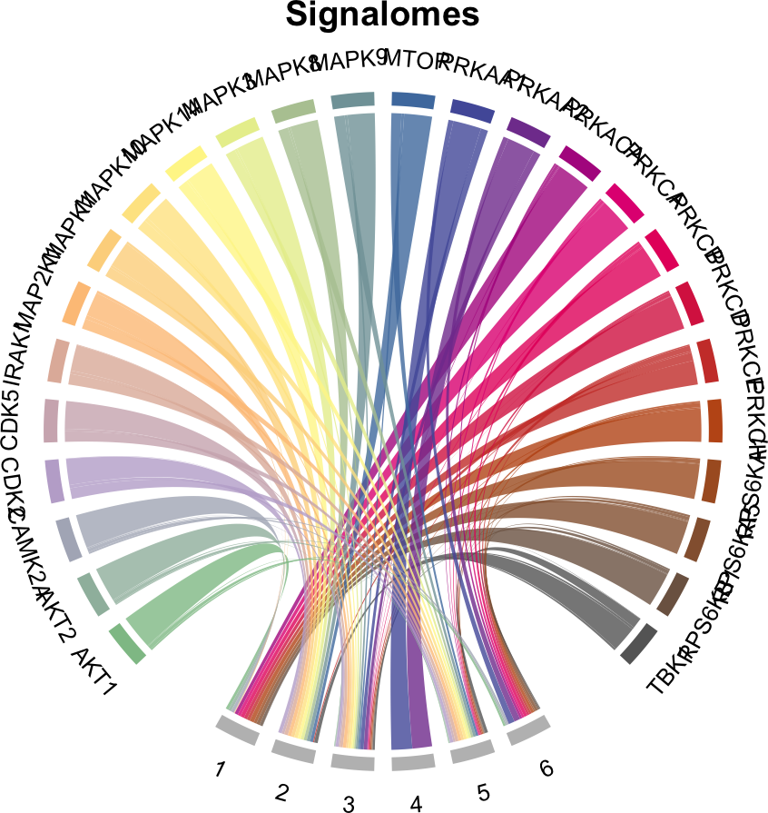

## 0.6 Generate signalome map

We can also visualise the relative contribution of each kinase towards the regulation of protein modules by plotting a balloon plot. In the balloon plot, the size of the balloons denote the percentage magnitude of kinase regulation in each module.

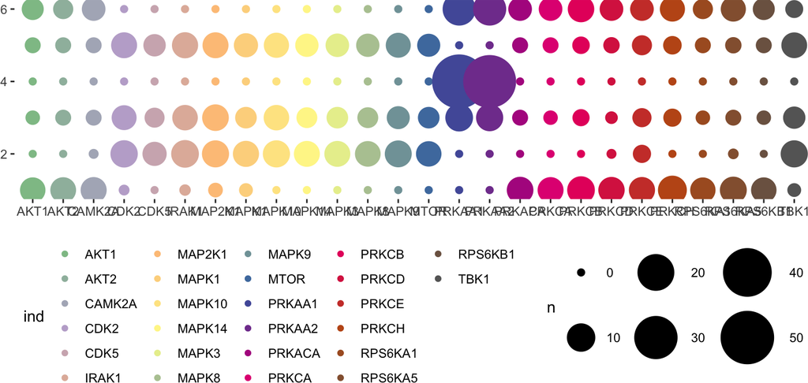

```r
my_color_palette <- grDevices::colorRampPalette(RColorBrewer::brewer.pal(8, "Accent"))
kinase_all_color <- my_color_palette(ncol(L6.matrices$combinedScoreMatrix))
names(kinase_all_color) <- colnames(L6.matrices$combinedScoreMatrix)
kinase_signalome_color <- kinase_all_color[colnames(L6.predMat)]

dftoPlot_signalome <- stack(Signalomes_results$kinaseSubstrates)
modules <- Signalomes_results$proteinModule
names(modules) <- sapply(strsplit(as.character(names(Signalomes_results$proteinModules)), ";"), "[[", 1)
dftoPlot_signalome$cluster <- modules[dftoPlot_signalome$values]

dftoPlot_balloon_bycluster <- dftoPlot_signalome
dftoPlot_balloon_bycluster <- na.omit(dftoPlot_balloon_bycluster) %>% dplyr::count(cluster, ind)
dftoPlot_balloon_bycluster$ind <- as.factor(dftoPlot_balloon_bycluster$ind)
dftoPlot_balloon_bycluster$cluster <- as.factor(dftoPlot_balloon_bycluster$cluster)
dftoPlot_balloon_bycluster <- tidyr::spread(dftoPlot_balloon_bycluster, ind, n)[,-1]
dftoPlot_balloon_bycluster[is.na(dftoPlot_balloon_bycluster)] <- 0

dftoPlot_balloon_bycluster <- do.call(rbind, lapply(1:nrow(dftoPlot_balloon_bycluster), function(x) {

        res <- sapply(dftoPlot_balloon_bycluster[x,], function(y) y/sum(dftoPlot_balloon_bycluster[x,])*100)

}))

dftoPlot_balloon_bycluster <- reshape2::melt(as.matrix(dftoPlot_balloon_bycluster))
colnames(dftoPlot_balloon_bycluster) <- c("cluster", "ind", "n")

ggplot(dftoPlot_balloon_bycluster, aes(x = ind, y = cluster)) +
        geom_point(aes(col=ind, size=n)) +
        scale_color_manual(values=kinase_signalome_color) +
        scale_size_continuous(range = c(2, 17)) +
        theme_classic() +
        theme(
                aspect.ratio=0.25,
                legend.position = "bottom",
                axis.line = element_blank(),
                axis.title = element_blank(),
                panel.grid.major.x = element_blank(),
                panel.grid.minor.x = element_blank())
```

### 0.6.1 Generate signalome network

Finally, we can also plot the signalome network that illustrates the connectivity between kinase signalome networks.

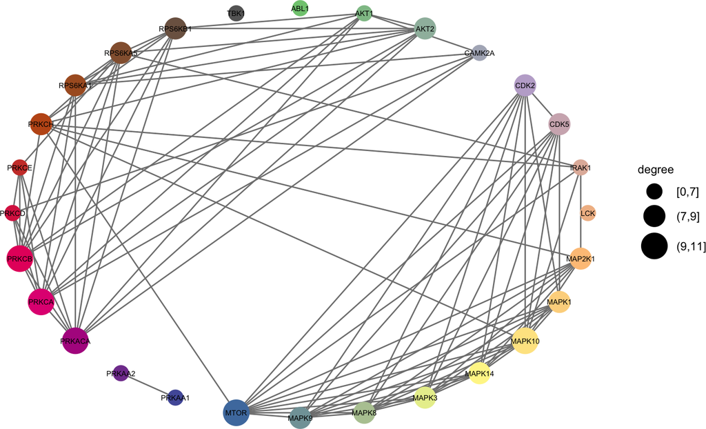

```r
threskinaseNetwork = 0.9
signalomeKinase <- colnames(L6.predMat)
kinase_cor <- stats::cor(L6.matrices$combinedScoreMatrix)

cor_kinase_mat <- kinase_cor
diag(cor_kinase_mat) <- 0
kinase_network <- lapply(1:ncol(cor_kinase_mat), function(x) names(which(cor_kinase_mat[,x] > threskinaseNetwork)))
names(kinase_network) <- colnames(cor_kinase_mat)

cor_kinase_mat <- apply(cor_kinase_mat, 2, function(x) x  > threskinaseNetwork)
cor_kinase_mat[cor_kinase_mat == F] <- 0
cor_kinase_mat[cor_kinase_mat == T] <- 1

library(network)
links <- reshape2::melt(cor_kinase_mat)
links <- links[links$value == 1,]
res <- sapply(1:length(links$Var1), function(x) { kinase_cor[rownames(kinase_cor) == links$Var1[x], colnames(kinase_cor) == links$Var2[x]]
})
links$cor <- res
colnames(links) <- c("source", "target", "binary", "cor")

network <- network::network(cor_kinase_mat, directed=F)
GGally::ggnet2(network,
       node.size=10,
       node.color=kinase_all_color,
       edge.size = 0.5,
       size = "degree",
       size.cut=3,
       label=colnames(cor_kinase_mat),
       label.size=2,
       mode="circle",
       label.color="black")
```